# Project Python Foundations: FoodHub Data Analysis

### Context

The number of restaurants in New York is increasing day by day. Lots of students and busy professionals rely on those restaurants due to their hectic lifestyles. Online food delivery service is a great option for them. It provides them with good food from their favorite restaurants. A food aggregator company FoodHub offers access to multiple restaurants through a single smartphone app.

The app allows the restaurants to receive a direct online order from a customer. The app assigns a delivery person from the company to pick up the order after it is confirmed by the restaurant. The delivery person then uses the map to reach the restaurant and waits for the food package. Once the food package is handed over to the delivery person, he/she confirms the pick-up in the app and travels to the customer's location to deliver the food. The delivery person confirms the drop-off in the app after delivering the food package to the customer. The customer can rate the order in the app. The food aggregator earns money by collecting a fixed margin of the delivery order from the restaurants.

### Objective

The food aggregator company has stored the data of the different orders made by the registered customers in their online portal. They want to analyze the data to get a fair idea about the demand of different restaurants which will help them in enhancing their customer experience. Suppose you are hired as a Data Scientist in this company and the Data Science team has shared some of the key questions that need to be answered. Perform the data analysis to find answers to these questions that will help the company to improve the business.

### Data Description

The data contains the different data related to a food order. The detailed data dictionary is given below.

### Data Dictionary

- order_id: Unique ID of the order
- customer_id: ID of the customer who ordered the food
- restaurant_name: Name of the restaurant
- cuisine_type: Cuisine ordered by the customer
- cost_of_the_order: Cost of the order
- day_of_the_week: Indicates whether the order is placed on a weekday or weekend (The weekday is from Monday to Friday and the weekend is Saturday and Sunday)
- rating: Rating given by the customer out of 5
- food_preparation_time: Time (in minutes) taken by the restaurant to prepare the food. This is calculated by taking the difference between the timestamps of the restaurant's order confirmation and the delivery person's pick-up confirmation.
- delivery_time: Time (in minutes) taken by the delivery person to deliver the food package. This is calculated by taking the difference between the timestamps of the delivery person's pick-up confirmation and drop-off information

### Let us start by importing the required libraries

```python
# Installing the libraries with the specified version.
!pip install numpy==1.25.2 pandas==1.5.3 matplotlib==3.7.1 seaborn==0.13.1 -q --user
```

**Note**: *After running the above cell, kindly restart the notebook kernel and run all cells sequentially from the start again.*

```python
# import libraries for data manipulation
import numpy as np
import pandas as pd

# import libraries for data visualization
import matplotlib.pyplot as plt
import seaborn as sns
```

### Understanding the structure of the data

```python
# uncomment and run the following lines for Google Colab
from google.colab import drive
drive.mount('/content/drive')
```

```python
# Write your code here to read the data

#data = pd.read_csv('/content/drive/MyDrive/FoodHub/foodhub_oder.csv')
data = pd.read_csv("/content/drive/MyDrive/FoodHub/foodhub_order.csv")
```

```python
# Write your code here to view the first 5 rows
#To get the first 5 rows, the head() function will be used
data.head()
```

|  | order_id | customer_id | restaurant_name | cuisine_type | cost_of_the_order | day_of_the_week | rating | food_preparation_time | delivery_time |
| --- | --- | --- | --- | --- | --- | --- | --- | --- | --- |
| 0 | 1477147 | 337525 | Hangawi | Korean | 30.75 | Weekend | Not given | 25 | 20 |
| 1 | 1477685 | 358141 | Blue Ribbon Sushi Izakaya | Japanese | 12.08 | Weekend | Not given | 25 | 23 |
| 2 | 1477070 | 66393 | Cafe Habana | Mexican | 12.23 | Weekday | 5 | 23 | 28 |
| 3 | 1477334 | 106968 | Blue Ribbon Fried Chicken | American | 29.20 | Weekend | 3 | 25 | 15 |
| 4 | 1478249 | 76942 | Dirty Bird to Go | American | 11.59 | Weekday | 4 | 25 | 24 |

### **Question 1:** How many rows and columns are present in the data? [0.5 mark]

```python
# Write your code here
#To identify the number of rows and columns, the shape attributes will be used

print(data.shape)

print("There are", data.shape[0], 'rows and', data.shape[1], "columns.")
```

```
(1898, 9)
There are 1898 rows and 9 columns.
```

#### Observations:

# The data has 1898 rows and 9 columns

### **Question 2:** What are the datatypes of the different columns in the dataset? (The info() function can be used) [0.5 mark]

```python
# Write your code here
#To understand different data types in the dataset, the info() function will be used

data.info()
```

```
<class 'pandas.core.frame.DataFrame'>
RangeIndex: 1898 entries, 0 to 1897
Data columns (total 9 columns):
 #   Column                 Non-Null Count  Dtype
---  ------                 --------------  -----
 0   order_id               1898 non-null   int64
 1   customer_id            1898 non-null   int64
 2   restaurant_name        1898 non-null   object
 3   cuisine_type           1898 non-null   object
 4   cost_of_the_order      1898 non-null   float64
 5   day_of_the_week        1898 non-null   object
 6   rating                 1898 non-null   object
 7   food_preparation_time  1898 non-null   int64
 8   delivery_time          1898 non-null   int64
dtypes: float64(1), int64(4), object(4)
memory usage: 133.6+ KB
```

#### Observations:

There are 5 numeric (int and float) columns in the data and 4 object type columns

numerical columns: order_id, customer_id, food_preparation_time, delivery_time and 'cost of the order'

Object type: restaurant_name, cuisine_type, day_of_the_week and rating

### **Question 3:** Are there any missing values in the data? If yes, treat them using an appropriate method. [1 mark]

```python
# Write your code here
#The missing data can be identified using isnull() and sum()

print(data.isnull().sum())
```

```
order_id                 0
customer_id              0
restaurant_name          0
cuisine_type             0
cost_of_the_order        0
day_of_the_week          0
rating                   0
food_preparation_time    0
delivery_time            0
dtype: int64
```

#### Observations:

The dataset has no missing values in any of the columns

### **Question 4:** Check the statistical summary of the data. What is the minimum, average, and maximum time it takes for food to be prepared once an order is placed? [2 marks]

```python
# Write your code here
#To get the statistical summary of the data of numerical attributes, the describe() function will be used

print(data.describe().T)

#We can derive from the abobe invocation.. but the option to get 'food preparation time' stats can be as follows
print("\n\nFood Preparaion Time stats\n", data['food_preparation_time'].describe())
```

```
                        count          mean            std         min  \
order_id               1898.0  1.477496e+06     548.049724  1476547.00
customer_id            1898.0  1.711685e+05  113698.139743     1311.00
cost_of_the_order      1898.0  1.649885e+01       7.483812        4.47
food_preparation_time  1898.0  2.737197e+01       4.632481       20.00
delivery_time          1898.0  2.416175e+01       4.972637       15.00

                              25%         50%           75%         max
order_id               1477021.25  1477495.50  1.477970e+06  1478444.00
customer_id              77787.75   128600.00  2.705250e+05   405334.00
cost_of_the_order           12.08       14.14  2.229750e+01       35.41
food_preparation_time       23.00       27.00  3.100000e+01       35.00
delivery_time               20.00       25.00  2.800000e+01       33.00


Food Preparaion Time stats
 count    1898.000000
mean       27.371970
std         4.632481
min        20.000000
25%        23.000000
50%        27.000000
75%        31.000000
max        35.000000
Name: food_preparation_time, dtype: float64
```

#### Observations:

Once the order is placed, Food preparation time are as follows

Minimum: 20

Average Tme: 27.37

Max Time: 35

### **Question 5:** How many orders are not rated? [1 mark]

```python
# Write the code here
print("The unique values of the ratings are as follows\n", data['rating'].unique())
print ("\nValue Counts", data['rating'].value_counts())
print ("\nValue Counts Percentage", data['rating'].value_counts(normalize=True) * 100)
```

```
The unique values of the ratings are as follows
 ['Not given' '5' '3' '4']

Value Counts rating
Not given    736
5            588
4            386
3            188
Name: count, dtype: int64

Value Counts Percentage rating
Not given    38.777661
5            30.979979
4            20.337197
3             9.905163
Name: proportion, dtype: float64
```

#### Observations:

As shown above --> How many orders are not rated = 736 (38.77%)... .

data.info():

6 rating 1898 non-null object

This show that the ratings is currently stored as non numerical (categorical column) as an object type.

If a transaction is not rated by customer, it will be stored as "Not given"

Based on the data, the rating column has 4 distinct values...3, 4, 5 and 'Not given'...

Many customers have not rated the transactions ('Not given') (around 38.77%)... and those who rated seems to be happy customers since they rated as 5 (30.977%) and 4 (20.337%)... Among the rated customers,9.905% customers rated as 3...

As shown above --> How many orders are not rated = 736 (38.77%)... . This indicates that a large portion of customers have opted out from providing ratings.

### Exploratory Data Analysis (EDA)

### **Question 6:** Explore all the variables and provide observations on their distributions. (Generally, histograms, boxplots, countplots, etc. are used for univariate exploration.) [9 marks]

```
Duplicate order Ids:  0

Repeated Customers:  698
Unique Customers:  1200
Top 5 Customers by Number of Orders:

customer_id
52832     13
47440     10
83287      9
250494     8
259341     7
Name: count, dtype: int64
```

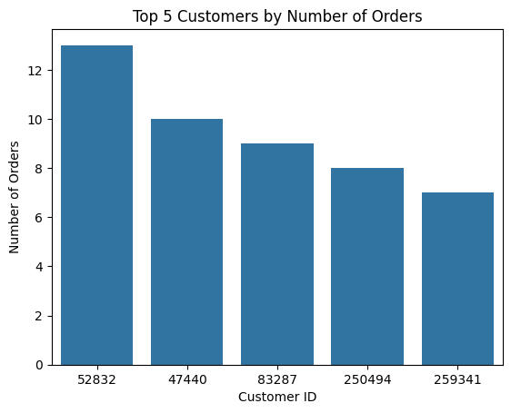

```
 The number of unique restaurants on the FoodHub platform: 178
```

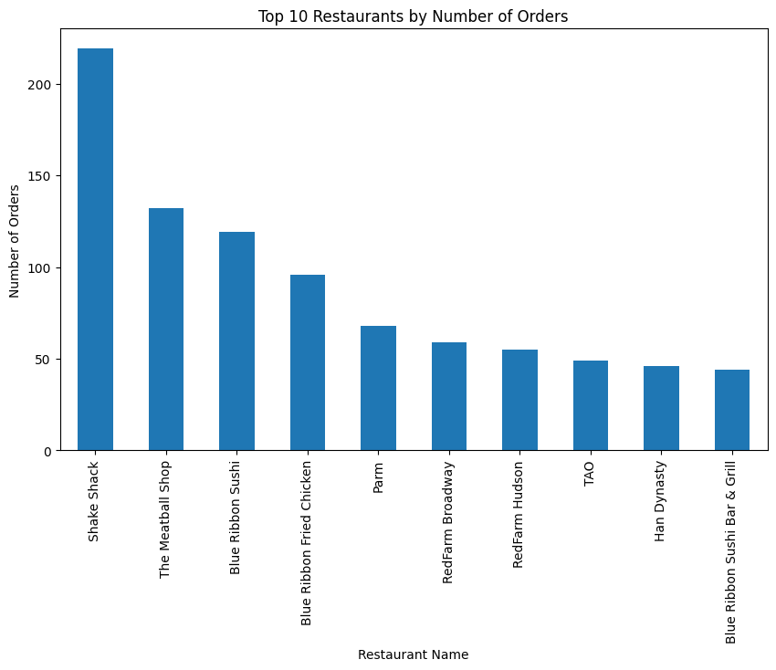

```
 The number of unique cuisine types on the FoodHub platform: 14
```

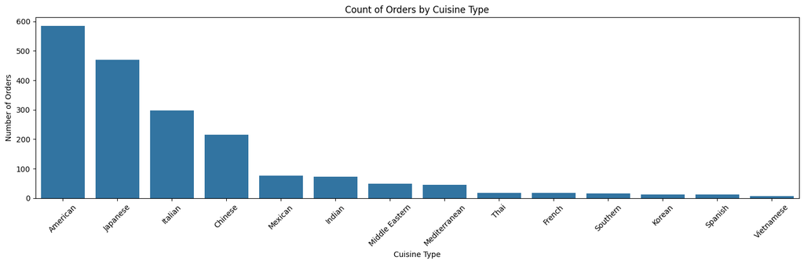

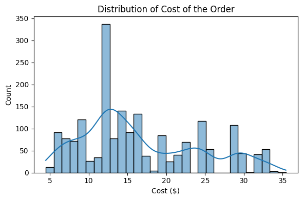

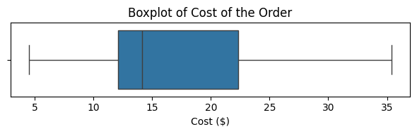

```
 The unique values in day of the week: ['Weekend' 'Weekday']
```

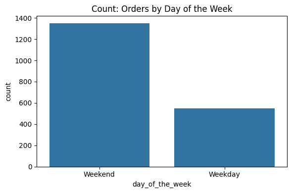

```
 The unique values in 'rating' column: ['Not given' '5' '3' '4']
```

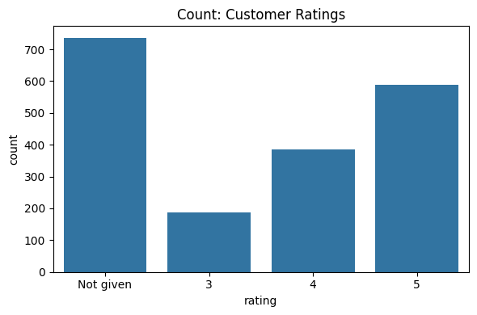

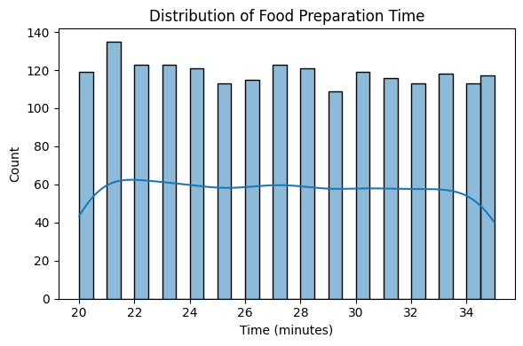

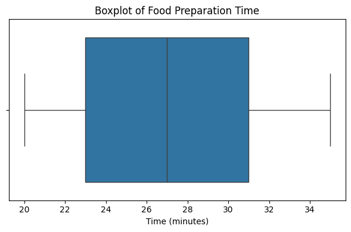

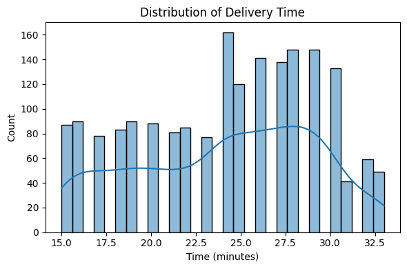

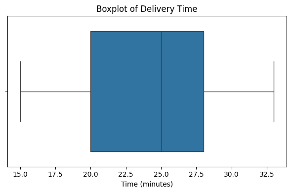

```python
# Write the code here
# As part of univariate, we will perform the analysis on each column/attribute

#1. Order_Id
#We will check if there are any duplicate order ids
print("Duplicate order Ids: ", data['order_id'].duplicated().sum())

#2. Customer_id
#Now we will do analysis on customer_id
print("\nRepeated Customers: ", data['customer_id'].duplicated().sum())
print("Unique Customers: ", data['customer_id'].nunique())

top_customers = data['customer_id'].value_counts().head(5)
print("Top 5 Customers by Number of Orders:\n")
print(top_customers)

#Plot the top 5 customers
sns.barplot(x=top_customers.index.astype(str), y=top_customers.values)
plt.title('Top 5 Customers by Number of Orders')
plt.xlabel('Customer ID')
plt.ylabel('Number of Orders')
plt.show()

#3. Restaurant name related
#Let us see how many unique restaurant names are part of Foodhub
print("\n The number of unique restaurants on the FoodHub platform:", data['restaurant_name'].nunique())

#Plot the top 5 restaurants
top_restaurants = data['restaurant_name'].value_counts().head(10)
top_restaurants.plot(kind='bar', figsize=(10, 6))
plt.title('Top 10 Restaurants by Number of Orders')
plt.xlabel('Restaurant Name')
plt.ylabel('Number of Orders')
plt.show()

#4. Cuisine Type
#Let us see how many unique cuisine types are part of Foodhub
print("\n The number of unique cuisine types on the FoodHub platform:", data['cuisine_type'].nunique())

# Plot countplot for cuisine type
plt.figure(figsize=(15, 5))
plt.xticks(rotation=45)
sns.countplot(x='cuisine_type', data=data, order=data['cuisine_type'].value_counts().index)
plt.title('Count of Orders by Cuisine Type')
plt.xlabel('Cuisine Type')
plt.ylabel('Number of Orders')
plt.tight_layout()
plt.show()

#5. Let us try to analyze cost of the order now... by having Histogram and box plot
#Histogram for cost of the order
plt.figure(figsize=(6, 4))
sns.histplot(data['cost_of_the_order'], bins=30, kde=True)
plt.title('Distribution of Cost of the Order')
plt.xlabel('Cost ($)')
plt.tight_layout()
plt.show()

# Boxplot for Cost of the Order
plt.figure(figsize=(6, 2))
sns.boxplot(x=data['cost_of_the_order'])
plt.title('Boxplot of Cost of the Order')
plt.xlabel('Cost ($)')
plt.tight_layout()
plt.show()

#6. Day of the week
print("\n The unique values in day of the week:", data['day_of_the_week'].unique())

#countplot
plt.figure(figsize=(6, 4))
sns.countplot(x='day_of_the_week', data=data)
plt.title('Count: Orders by Day of the Week')
plt.tight_layout()
plt.show()

#7. Ratings
print("\n The unique values in 'rating' column:", data['rating'].unique())

#Countplot: Rating
plt.figure(figsize=(6, 4))
sns.countplot(x='rating', data=data, order=['Not given', '3', '4', '5'])
plt.title('Count: Customer Ratings')
plt.tight_layout()
plt.show()

#8. Let us try to analyze 'Food Preparation Time'... by having Histogram and box plot
# Histogram
plt.figure(figsize=(6, 4))
sns.histplot(data['food_preparation_time'], bins=30, kde=True)
plt.title('Distribution of Food Preparation Time')
plt.xlabel('Time (minutes)')
plt.tight_layout()
plt.show()

# Boxplot
plt.figure(figsize=(6, 4))
sns.boxplot(x=data['food_preparation_time'])
plt.title('Boxplot of Food Preparation Time')
plt.xlabel('Time (minutes)')
plt.tight_layout()
plt.show()

#9. Histogram and Boxplot for Delivery Time
# Histogram
plt.figure(figsize=(6, 4))
sns.histplot(data['delivery_time'], bins=30, kde=True)
plt.title('Distribution of Delivery Time')
plt.xlabel('Time (minutes)')
plt.tight_layout()
plt.show()

# Boxplot
plt.figure(figsize=(6, 4))
sns.boxplot(x=data['delivery_time'])
plt.title('Boxplot of Delivery Time')
plt.xlabel('Time (minutes)')
plt.tight_layout()
plt.show()
```

**Observation:**

### **Question 7**: Which are the top 5 restaurants in terms of the number of orders received? [1 mark]

```
Top 5 Restaurants by Number of Orders:
restaurant_name
Shake Shack                  219
The Meatball Shop            132
Blue Ribbon Sushi            119
Blue Ribbon Fried Chicken     96
Parm                          68
Name: count, dtype: int64
```

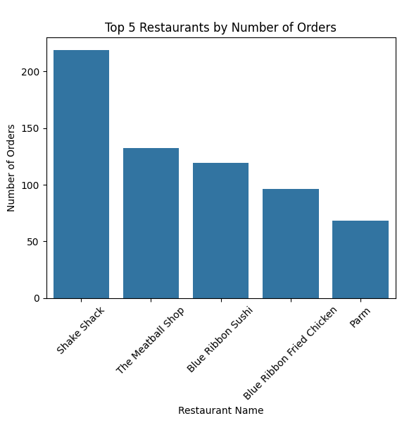

```python
# Write the code here
#Top 5 restaurants can be found by value_counts()

top_restaurants = data['restaurant_name'].value_counts().head(5)
print("Top 5 Restaurants by Number of Orders:")
print(top_restaurants)

#This can also be understood by plotting themin barplot
sns.barplot(x=top_restaurants.index, y=top_restaurants.values)
plt.title('\nTop 5 Restaurants by Number of Orders')
plt.xlabel('Restaurant Name')
plt.ylabel('Number of Orders')
plt.xticks(rotation=45)
plt.show();
```

#### Observations:

Top 5 Restaurants by Number of Orders: restaurant_name Shake Shack 219

The Meatball Shop 132

Blue Ribbon Sushi 119

Blue Ribbon Fried Chicken 96

Parm 68

Shake Shack leads the chart with 219 orders, followed by The Meatball Shop, Blue Ribbon Sushi, Blue Ribbon Fred Chicken and Parm.... These restaurants are the most in-demand in FoodHub platform.

### **Question 8**: Which is the most popular cuisine on weekends? [1 mark]

```
The unique values of the the days are as follows
 ['Weekend' 'Weekday']

Value Counts day_of_the_week
Weekend    1351
Weekday     547
Name: count, dtype: int64

Cuisine order count on weekends:
cuisine_type
American          415
Japanese          335
Italian           207
Chinese           163
Mexican            53
Indian             49
Middle Eastern     32
Mediterranean      32
Thai               15
French             13
Korean             11
Southern           11
Spanish            11
Vietnamese          4
Name: count, dtype: int64
```

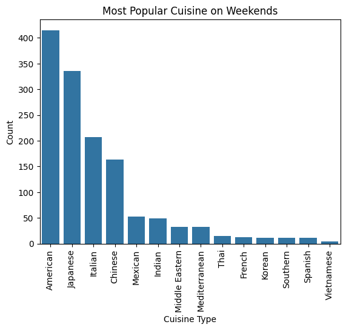

```python
# Write the code here
#To answer this, we need to get the data of the weekend.
print("The unique values of the the days are as follows\n", data['day_of_the_week'].unique())
print ("\nValue Counts", data['day_of_the_week'].value_counts())

# Filter data for weekends only
weekend_data = data[data['day_of_the_week'] == 'Weekend']

# Find the most popular cuisine on weekends
weekend_cuisine_counts = weekend_data['cuisine_type'].value_counts()

#Now we are going to have the count plot to understand the most popular cuisine
sns.countplot(data=weekend_data, x='cuisine_type', order=weekend_cuisine_counts.index)
plt.title('Most Popular Cuisine on Weekends')
plt.xlabel('Cuisine Type')
plt.ylabel('Count')
plt.xticks(rotation=90);

#This can also be noticed by just printing the weekend_cuisine_counts
print("\nCuisine order count on weekends:")
print(weekend_cuisine_counts)
```

#### Observations:

The most popular cuisine on weekend is American, based on the number of orders (415)...(American cuisine followed by Japanese and Italian). This indicates that there is a strong demand for American food on weekends by Foodhub customers.

### **Question 9**: What percentage of the orders cost more than 20 dollars? [2 marks]

```
Total number of Orders:  1898
Orders greater than 20:  555
Orders less than equal 20:  1343

Percentage of orders greater than 20:  29.24 %
```

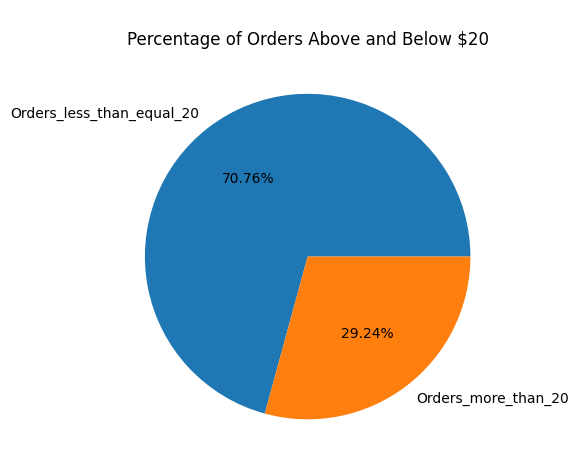

```python
# Write the code here
orders_gt_20 = data[data['cost_of_the_order'] > 20].shape[0]
orders_le_20 = data.shape[0] - orders_gt_20

print("\nTotal number of Orders: ", data.shape[0], "\nOrders greater than 20: ", orders_gt_20, "\nOrders less than equal 20: ", orders_le_20)

orders_gt_20_percentage = (orders_gt_20 / data.shape[0]) * 100
print("\nPercentage of orders greater than 20: ", round(orders_gt_20_percentage, 2), "%")

#This can be represented in Pie chart as well
labels = ['Orders_less_than_equal_20', 'Orders_more_than_20']
sizes = [orders_le_20, orders_gt_20]

plt.pie(sizes, labels=labels, autopct='%1.2f%%')
plt.title('\nPercentage of Orders Above and Below $20')
plt.tight_layout()
plt.show()
```

#### Observations:

The total number of orders can be derived from data.shape[0] = 1898.

Out of which 555 orders are greater than 20; which means 29.24% of the orders are above 20... This indicates that nearly one-third of the orders fall into orders greathan 20.

### **Question 10**: What is the mean order delivery time? [1 mark]

```python
# Write the code here
mean_delivery_time = data['delivery_time'].mean()
print("Mean Delivery Time:", round(mean_delivery_time, 2))

#This can also be observed from mean parameter of describe
print("\nDelivery Time stats:\n", data['delivery_time'].describe())
```

```
Mean Delivery Time: 24.16

Delivery Time stats:
 count    1898.000000
mean       24.161749
std         4.972637
min        15.000000
25%        20.000000
50%        25.000000
75%        28.000000
max        33.000000
Name: delivery_time, dtype: float64
```

#### Observations:

The mean order delivery time: 24.16

### **Question 11:** The company has decided to give 20% discount vouchers to the top 3 most frequent customers. Find the IDs of these customers and the number of orders they placed. [1 mark]

```python
# Write the code here
#Top 3 customers can be found by using value_counts() and head...
top_3_customers = data['customer_id'].value_counts().head(3).reset_index()

top_3_customers.columns = ['customer_id', 'Number of Orders']

print("Top 3 customers eligible for 20% discount:\n")
top_3_customers
```

```
Top 3 customers eligible for 20% discount:
```

|  | customer_id | Number of Orders |
| --- | --- | --- |
| 0 | 52832 | 13 |
| 1 | 47440 | 10 |
| 2 | 83287 | 9 |

#### Observations:

The top 3 customers eligible for 20% discount (along with their number of orders) are as follows:

- "Customer with customer_id 52832 with 13 orders"
- "Customer with customer_id 47440 with 10 orders"
- "Customer with customer_id 83287 with 9 orders"

### **Question 12**: Perform a multivariate analysis to explore relationships between the important variables in the dataset. (It is a good idea to explore relations between numerical variables as well as relations between numerical and categorical variables) [10 marks]

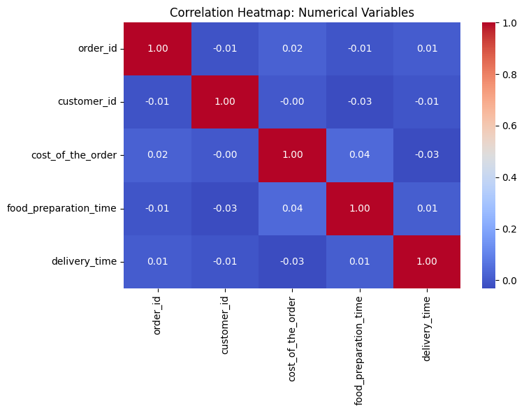

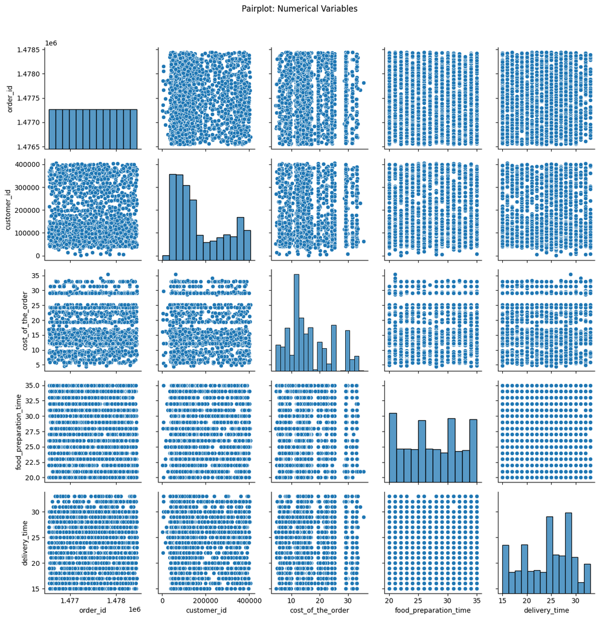

```
 Median cost of Various Cuisines:
 cuisine_type
American          14.120
Japanese          14.070
Italian           14.480
Chinese           14.120
Mexican           15.570
Indian            16.150
Middle Eastern    16.300
Mediterranean     13.995
Thai              19.350
French            20.470
Southern          16.110
Korean            12.180
Spanish           16.520
Vietnamese        12.130
Name: cost_of_the_order, dtype: float64
```

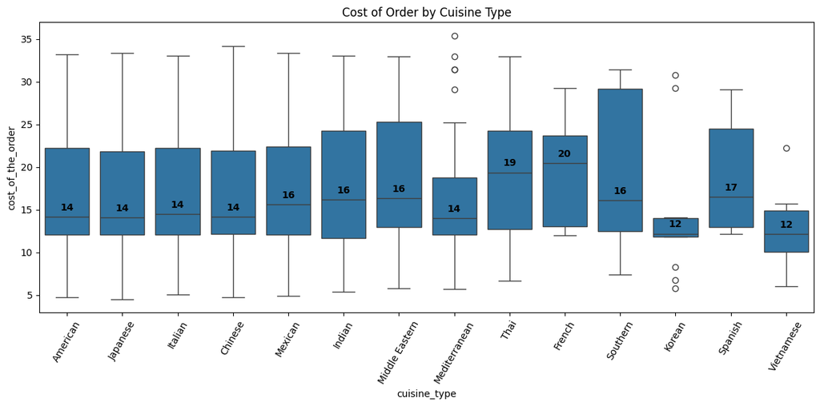

```
 Median Preparation Time for various Cuisines:
 cuisine_type
American          27.0
Japanese          27.5
Italian           28.0
Chinese           27.0
Mexican           26.0
Indian            27.0
Middle Eastern    27.0
Mediterranean     27.0
Thai              28.0
French            25.5
Southern          26.0
Korean            25.0
Spanish           27.5
Vietnamese        25.0
Name: food_preparation_time, dtype: float64
```

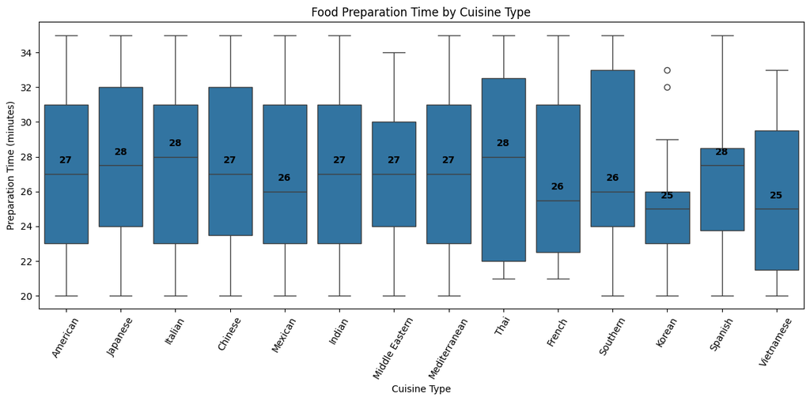

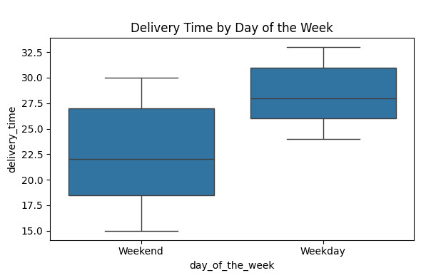

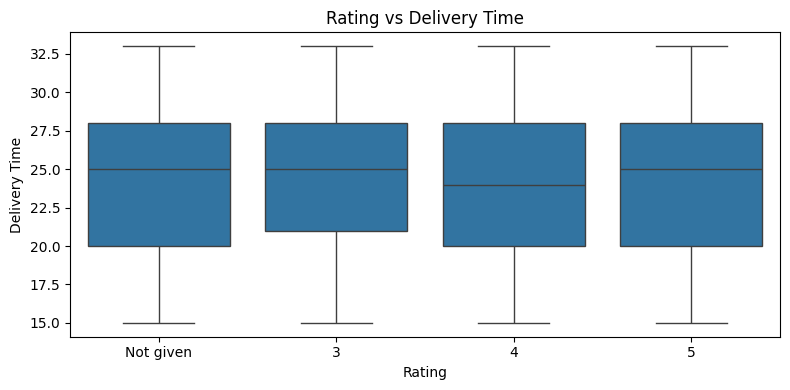

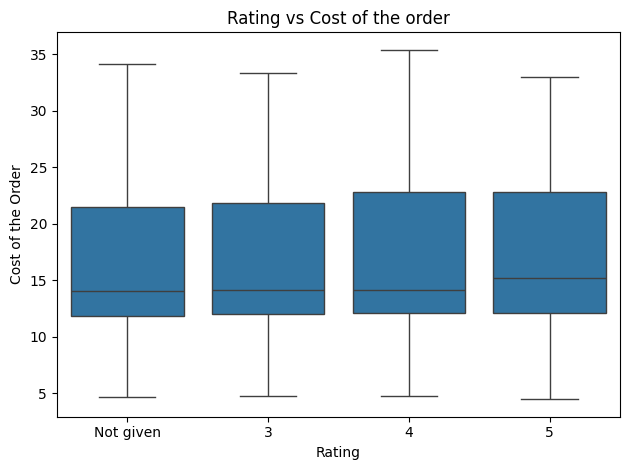

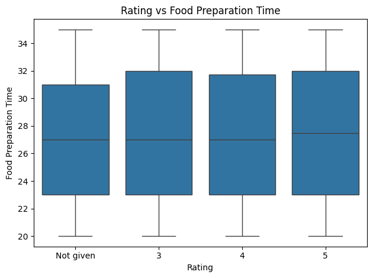

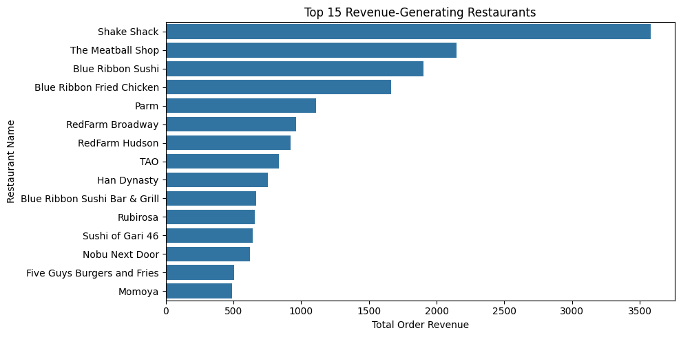

```python
# Write the code here

# 1. We will start by plotting the heatmap to understand the Correlation between numerical variables...
numerical_cols = ['order_id', 'customer_id', 'cost_of_the_order', 'food_preparation_time', 'delivery_time']
plt.figure(figsize=(8, 6))
sns.heatmap(data[numerical_cols].corr(), annot=True, cmap='coolwarm', fmt=".2f")
plt.title('Correlation Heatmap: Numerical Variables')
plt.tight_layout()
plt.show()

#pairplot
sns.pairplot(data[numerical_cols])
plt.suptitle('Pairplot: Numerical Variables', y=1.02)
plt.tight_layout()
plt.show()

# 2. Boxplot: cost_of_the_order vs cuisine_type
# Compute median cost_of_the_order time for each cuisine
plot_order  = data['cuisine_type'].value_counts().index
medians = data.groupby('cuisine_type')['cost_of_the_order'].median().reindex(plot_order)
print("\n Median cost of Various Cuisines:\n",medians)

plt.figure(figsize=(12, 6))
ax = sns.boxplot(x='cuisine_type', y='cost_of_the_order', data=data, order=plot_order)
plt.title('Cost of Order by Cuisine Type')
plt.xticks(rotation=60)

# Annotate the median value above each box
for i, cuisine in enumerate(medians.index):
    median_val = medians[cuisine]
    ax.text(i, median_val + 0.5, f'{median_val:.0f}', ha='center', va='bottom', color='black', fontweight='bold')

plt.tight_layout()
plt.show()

## Boxplot: Food Preparation Time vs Cuisine Type
# Compute median preparation time for each cuisine
plot_order  = data['cuisine_type'].value_counts().index
medians = data.groupby('cuisine_type')['food_preparation_time'].median().reindex(plot_order)
print("\n Median Preparation Time for various Cuisines:\n",medians)

plt.figure(figsize=(12, 6))
ax = sns.boxplot(x='cuisine_type', y='food_preparation_time', data=data, order=plot_order)
plt.title('Food Preparation Time by Cuisine Type')
plt.xlabel('Cuisine Type')
plt.ylabel('Preparation Time (minutes)')
plt.xticks(rotation=60)

# Annotate the median value above each box
for i, cuisine in enumerate(medians.index):
    median_val = medians[cuisine]
    ax.text(i, median_val + 0.5, f'{median_val:.0f}', ha='center', va='bottom', color='black', fontweight='bold')
plt.tight_layout()
plt.show();

# 3. Boxplot: delivery_time vs day_of_the_week
plt.figure(figsize=(6, 4))
sns.boxplot(x='day_of_the_week', y='delivery_time', data=data)
plt.title('\nDelivery Time by Day of the Week')
plt.tight_layout()
plt.show()


#. Now let us evaluate ratings vs other parameters
# Replace 'Not given' with np.nan and convert to float
data['rating_cleaned'] = data['rating'].replace('Not given', np.nan).astype(float)

# 5. Rating vs Delivery time
plt.figure(figsize=(8, 4))

#intentionally included 'Not given' in the plot to understand the delivery_time for Not given vs other ratings
sns.boxplot(x='rating', y='delivery_time', data=data, order=['Not given', '3', '4', '5'])
plt.title('Rating vs Delivery Time')
plt.xlabel('Rating')
plt.ylabel('Delivery Time')
plt.tight_layout()
plt.show()

# 6. Rating vs Cost of the Order
sns.boxplot(x='rating', y='cost_of_the_order', data=data, order=['Not given', '3', '4', '5'])
plt.title('Rating vs Cost of the order')
plt.xlabel('Rating')
plt.ylabel('Cost of the Order')
plt.tight_layout()
plt.show()

# 7. Rating vs Preparation Time
sns.boxplot(x='rating', y='food_preparation_time', data=data, order=['Not given', '3', '4', '5'])
plt.title('Rating vs Food Preparation Time')
plt.xlabel('Rating')
plt.ylabel('Food Preparation Time')
plt.tight_layout()
plt.show()

#8. Let us see from Revenue perspective...
# Group by restaurant and sum cost to find total revenue per restaurant
revenue_by_restaurant = data.groupby('restaurant_name')['cost_of_the_order'].sum().sort_values(ascending=False).head(15)

# Plot the top 15 revenue-generating restaurants
plt.figure(figsize=(10, 5))
sns.barplot(x=revenue_by_restaurant.values, y=revenue_by_restaurant.index)
plt.title('Top 15 Revenue-Generating Restaurants')
plt.xlabel('Total Order Revenue')
plt.ylabel('Restaurant Name')
plt.tight_layout()
plt.show();
```

**Observations:**

   Note: Median values are rounded to nearest whole number in the plot for clarity; exact values used in observations.

a. French cusine has the highest median cost (approx 20.47) followed by Thai (19.35)

b. Vietnamese (12.13) and Korean (12.18) are the lowest median-cost cuisines (~$12), suggesting more budget-friendly meals

c. Most cuisines fall in the $13-$16 range...

4. Cuisine Type Vs Food Preparation Time

a. From the box plot, it shows that Italian, Thai cuisines have highest average prep time (28)

b. Vietnamese and Koreans have the lowest average prep time (25)

c. Overall variation of preparation_time among different cuisine_type is small indicating that the food_prep_time is consistent acorss different cuisine_type

### **Question 13:** The company wants to provide a promotional offer in the advertisement of the restaurants. The condition to get the offer is that the restaurants must have a rating count of more than 50 and the average rating should be greater than 4. Find the restaurants fulfilling the criteria to get the promotional offer. [3 marks]

```
Restaurants fulfilling the criteria to get the promotional offer are as follows:
             restaurant_name  rating_count  average_rating
0                Shake Shack           133        4.278195
1          The Meatball Shop            84        4.511905
2          Blue Ribbon Sushi            73        4.219178
3  Blue Ribbon Fried Chicken            64        4.328125
```

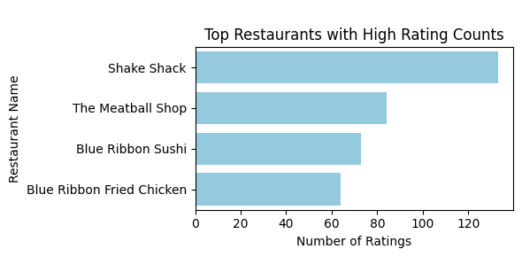

```python
# Write the code here
# From the earlier questions, it is understood that rating column is saved as Object and some of the values are stored as 'Not given'
# So first this needs to be converted to 'nan'...
data['rating_cleaned'] = data['rating'].replace('Not given', np.nan)

#since all the values belongs to ratings are numeric now,  this can be converted to numeric
data['rating_cleaned'] = data['rating_cleaned'].astype(float)

#Identify the restaurants which have more than 50 ratings
restaurant_rating_stats = data.groupby('restaurant_name')['rating_cleaned'].agg(['count', 'mean']).reset_index()
restaurant_rating_stats.columns = ['restaurant_name', 'rating_count', 'average_rating']

#Filter based on the criteria (rating_count > 50 and average_rating > 4)
discount_offer_eligible_restaurants = restaurant_rating_stats[(restaurant_rating_stats['rating_count'] > 50) & (restaurant_rating_stats['average_rating'] > 4)]

#This is to provide the list in ascending order (of the rating_count) with resetting the index
discount_offer_eligible_restaurants_sorted  = discount_offer_eligible_restaurants.sort_values(by='rating_count', ascending=False)
discount_offer_eligible_restaurants_sorted  = discount_offer_eligible_restaurants_sorted.reset_index(drop=True)

print("\nRestaurants fulfilling the criteria to get the promotional offer are as follows:")
print(discount_offer_eligible_restaurants_sorted)

# Simple horizontal bar chart using Seaborn
plt.figure(figsize=(6, 3))
sns.barplot(
    data=discount_offer_eligible_restaurants_sorted,
    x='rating_count',
    y='restaurant_name',
    color='skyblue'
)
plt.title('\nTop Restaurants with High Rating Counts')
plt.xlabel('Number of Ratings')
plt.ylabel('Restaurant Name')
plt.tight_layout()
plt.show()
```

#### Observations:

The 4 restaurants that qualify for the promotional offer are as follows: SHake Shack The Meatball shop Blue Ribbon Sushi Blue Ribbon Fried Chicken

'Shake Shack' being the highest number of ratings (133) while the 'Meatball Shop' being the highest average rating (4.5119).

All the four restaurants mentioned above are doing good interms of number of ratings as well as good average rating.

### **Question 14:** The company charges the restaurant 25% on the orders having cost greater than 20 dollars and 15% on the orders having cost greater than 5 dollars. Find the net revenue generated by the company across all orders. [3 marks]

```python
# Write the code here
#To calculate revenue generated by company, we can introduce a colum order_revenue in the dataframe (data) and sume the revenue.
# To calcuate the revenue, the 'calculate_order_revenue() function will be defined

#Function to calculcate the revenue
def calculate_order_revenue(order_cost):
    if order_cost > 20:
        return order_cost * 0.25  # 25% discount for orders greater than 20
    elif order_cost > 5:
       return order_cost * 0.15  # 15% discount for orders greater than 5
    else:
        return 0  # No discount for orders less than or equal to 5 or 20

#The above function can be applied for each row as follows and the result will be assigned to data['order_revenue'] column
data['order_revenue']  = data['cost_of_the_order'].apply(calculate_order_revenue)

#Sum total revenue
total_revenue = data['order_revenue'].sum()

print("Total Revenue Generated by the Company:", round(total_revenue, 2))
```

```
Total Revenue Generated by the Company: 6166.3
```

#### Observations:

The company generates revenue by taking a commission from each order. Based on the rules provided:

Orders > 20 are charged 25%

Orders between 5 and 20 are charged 15%

The total revenue generated from all orders is $6,166.30.

### **Question 15:** The company wants to analyze the total time required to deliver the food. What percentage of orders take more than 60 minutes to get delivered from the time the order is placed? (The food has to be prepared and then delivered.) [2 marks]

```
Number of orders taking total delivery time more than 60 mins: 200 and total number of orders: 1898
Percentage of orders taking total delivery time more than 60 minutes: 10.54%
```

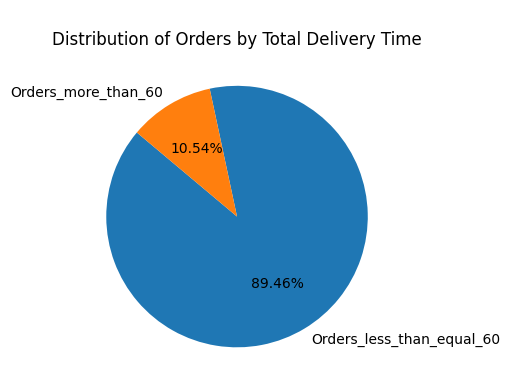

```python
# Write the code here
# Calculate total time from order to delivery
#we will calculate the 'total delivery time' by taking food_preparation_time and 'delivery_time' into consideration

data['total_delivery_time'] = data['food_preparation_time'] + data['delivery_time']

# Find percentage of orders taking more than 60 minutes
orders_above_60 = data[data['total_delivery_time'] > 60].shape[0]
total_orders = data.shape[0]
percentage_above_60 = (orders_above_60 / total_orders) * 100
print("Number of orders taking total delivery time more than 60 mins:", orders_above_60, "and total number of orders:", total_orders)
print(f"Percentage of orders taking total delivery time more than 60 minutes: {round(percentage_above_60, 2)}%")

#This can be represented in Pie chart as follows

labels = ['Orders_less_than_equal_60', 'Orders_more_than_60']
sizes = [total_orders - orders_above_60, orders_above_60]

# Create pie chart
plt.figure(figsize=(6, 4))
plt.pie(sizes, labels=labels, autopct='%1.2f%%', startangle=140)
plt.title('\nDistribution of Orders by Total Delivery Time')
plt.tight_layout()
plt.show()
```

#### Observations:

There are 200 orders which takes more than 60 mins of total delivery time (food_preparation_time + delivery_time) out of total number of orders 1898.

This is about 10.54% of orders exceeding 60 mins in total delivery time. This long of total delivery time may impact customer staisfaction.

### **Question 16:** The company wants to analyze the delivery time of the orders on weekdays and weekends. How does the mean delivery time vary during weekdays and weekends? [2 marks]

```python
# Write the code here
# All weekdays are represented using weekday...
print("The unique values of the the days are as follows\n", data['day_of_the_week'].unique())

#Calculcate mean delivery time for weekday and weekend...
mean_delivery_time_weekday = data[data['day_of_the_week'] != 'Weekend']['delivery_time'].mean()
mean_delivery_time_weekend = data[data['day_of_the_week'] == 'Weekend']['delivery_time'].mean()

print("\nMean Delivery Time on Weekdays:", round(mean_delivery_time_weekday, 2))
print("Mean Delivery Time on Weekends:", round(mean_delivery_time_weekend, 2))

#To think beyond the "delivery_time" and take a point from the earlier question (total_delivery_time)
#Let us see how this compares for weekday vs weekend..
mean_total_delivery_time_weekday = data[data['day_of_the_week'] != 'Weekend']['total_delivery_time'].mean()
mean_total_delivery_time_weekend = data[data['day_of_the_week'] == 'Weekend']['total_delivery_time'].mean()

print("\nMean Total Delivery Time on Weekdays:", round(mean_total_delivery_time_weekday, 2))
print("Mean Total Delivery Time on Weekends:", round(mean_total_delivery_time_weekend, 2))
```

```
The unique values of the the days are as follows
 ['Weekend' 'Weekday']

Mean Delivery Time on Weekdays: 28.34
Mean Delivery Time on Weekends: 22.47

Mean Total Delivery Time on Weekdays: 55.55
Mean Total Delivery Time on Weekends: 49.91
```

#### Observations:

The mean delivery time on weekdays is higher than on weekends. Even if we do the analysis on total delivery time (food_prepartion_time + delivery time), the similar gap exists.

This may be due to, more delivery personnael + food preparation staff are available on weekends compared to weekdays.

In addition the factor that may be helping is the traffic conditions on weekend may be lower compared to weekedays.

### Conclusion and Recommendations

### **Question 17:** What are your conclusions from the analysis? What recommendations would you like to share to help improve the business? (You can use cuisine type and feedback ratings to drive your business recommendations.) [6 marks]

**Conclusions:**

There are 178 unique restaurants that are partnered with FoodHub and 'ShakeShack' stands out interms of numbers of orders. Small group of restaurants are contributing in generating FoodHub revenue.

Around 14 unique types of cuisines are offered from Foodhub platform. American, Japanese and Italian are most frequently ordered cuisnes.. The least frequent being Vietnamese, Spanish.

The majority of orders are in the ranged of 10-20... This seems like economically within the budget ranges for middle class members.

The customers are ordering more during weekends compared to weekdays.

Many customers are showing their satisfaction by providing 5 rating. This proves that the customer satisfaction is high but a large portion of users are skipping and not providing the rating.

The median food preparation time is around 27 mins irrespective of the cuisine type. So the restaurants that are offered though FoodHub have consistency in their food preparation process.

The median delivery is around 24-25 minutes.. The food preparation time generally consistent irrespective of the cuisine_type, which suggests that variation in delivery time is more likely due to external factors (traffic, logistics) than restaurant performance.

The food preparation time or delivery time doesnt strongly influcne the ratings It was observed that even the orders with 5 ratings have slightly higher food preparation time...

### Recommendations:

- We can start from cstomer rating perspective. As many orders are not rated, the customers can be encouraged to provide the feedback by providing some small rewards for providing the feedback...
- Increase the marketing efforts on already highly demanded cuisine types like American, Japanese, Italian etc. The Foodhub can mix and match offers with low selling cuisines with these high demand ones so that more business can be extracted...
- Offer discounts through high performing restaurants like 'Shake Shack' and start displaying those apps in FoodHub app...
- In the analysis, it was identified that the food preparation time is consistent for different cuisine types, need to concentrate on how the food delivery time can be reduced. may be optimizing the routes/or improving algorithms for identifying delivery members closer to customer/restaurants